# kora

### add damping term

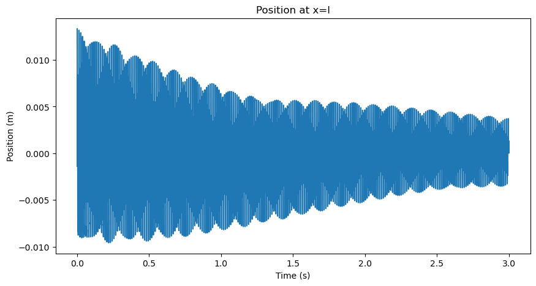

```python
def get_M(f, d, eta):
    mu_a = eta / rho_air
    return d/4 * np.sqrt(2 * np.pi * f / mu_a)

def calculate_Q(f, d, eta, rho_L, T_corde, E, I, delta_ve=3.5e-3, Q_th=7e3):
    M = get_M(f, d, eta)
    R = np.pi**2 * rho_air * f * d**2 / 2 * (np.sqrt(2)/M + 1 / (2 * M**2))
    Q_air_inv = R / (2 * np.pi * f * rho_L)
    Q_visc_inv = 4 * np.pi**2 * rho_L * E * I * f**2 * delta_ve / (T_corde**2)
    Q_th_inv = 1 / Q_th
    return 1 / (Q_air_inv + Q_visc_inv + Q_th_inv)

y_l = np.zeros(len(t_scale))

for i in range(len(t_scale)):
    for n in range(1, n_mode + 1):
        kn = get_k_n(n, L)
        fn = get_f_n(n, f_0, p_n)
        y_l[i] += get_q_n_0(n, L, h, l) * np.sin(kn * l)**2 * np.cos(2 * np.pi * fn * t_scale[i]) * np.exp(- np.pi * fn / calculate_Q(fn, diameter, eta, rho_L, T_corde, E, I) * t_scale[i])

# plot position
fig, ax = plt.subplots(figsize=(10, 5))
ax.plot(t_scale, y_l)
ax.set_xlabel('Time (s)')
ax.set_ylabel('Position (m)')
ax.set_title('Position at x=l')
plt.show()
```

```python
Audio(y_l, rate=sample_rate)
```

[interactive chart not shown]

## Vibration of a soundboard and a cavity

A simpliﬁed model with two degrees of freedom fairly reproduces the behavior of real instruments at low frequencies \begin{aligned} \mathbb{M} \ddot{y} + \mathbb{R} \dot{y} + \mathbb{K} y = \mathbb{F} \end{aligned} where $\mathbb{M}$ is the mass matrix, $\mathbb{R}$ is the damping matrix, $\mathbb{K}$ is the stiffness matrix, $\mathbb{F}$ is the force vector, $y$ is the displacement, \begin{aligned} \mathbb{M} = \begin{bmatrix} m_p & 0 \\ 0 & m_h \end{bmatrix}, \mathbb{R} = \begin{bmatrix} r_p & 0 \\ 0 & r_h \end{bmatrix}, \mathbb{K} = \begin{bmatrix} k_p+\mu A_p^2 & \mu A_h A_p \\ \mu A_h A_p & \mu A_h^2 \end{bmatrix}, \end{aligned}, where $m_p=M$ is the mass of the soundboard and bridge, $m_h$ is the mass of the air in the cavity, $r_p$ is the damping of the soundboard, $r_h$ is the damping of the air in the cavity, $k$ is the stiffness of the soundboard, $A_p$ is the surface of the soundboard, $A_h$ is the surface of the hold in the cavity, $\mu$ is the air mass per unit area.

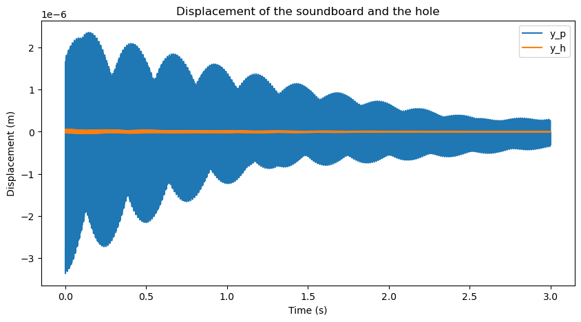

```python
m_h = rho_air * volume
stiffness = config['stiffness of the soundboard']
matrix_M = np.array([[M, 0], [0, m_h]])
matrix_R = np.array([[R_p, 0], [0, R_h]])
matrix_K = np.array([[stiffness + rho_air * A_p**2, rho_air * A_h * A_p],
              [rho_air * A_h * A_p, rho_air * A_h**2]])

eig_matrix = np.linalg.inv(matrix_M).dot(matrix_K)
eig_values, eig_vectors = np.linalg.eig(eig_matrix)
omega = np.sqrt(eig_values)
omega.sort()
omega = omega[1]

omega_p = np.sqrt(matrix_K[0,0] / matrix_M[0,0])
omega_h = np.sqrt(matrix_K[1,1] / matrix_M[1,1])
omega_a = np.sqrt(rho_air * A_p**2 / matrix_M[0,0])
omega_ph = np.sqrt(omega_a * omega_p)
gamma_h = R_h / m_h
gamma_p = R_p / M

D_c = (omega_p**2 - omega**2 + 1j * omega * gamma_p) * (omega_h**2 - omega**2 + 1j * omega * gamma_h) - omega_ph**4

# acceleration of the soundboard from y_l
a_l = np.zeros(len(t_scale))

for i in range(len(t_scale)):
    for n in range(1, n_mode + 1):
        kn = get_k_n(n, L)
        fn = get_f_n(n, f_0, p_n)
        a_l[i] += - (2 * np.pi * fn) ** 2 * get_q_n_0(n, L, h, l) * np.sin(kn * l)**2 * np.cos(2 * np.pi * fn * t_scale[i]) * np.exp(- np.pi * fn / calculate_Q(fn, diameter, eta, rho_L, T_corde, E, I) * t_scale[i])

force = M * a_l

# displacement of the soundboard y_p
y_p = force / M * (omega_h**2 - omega**2 + 1j * omega * gamma_h) / D_c

# displacement of the hole y_h
y_h = force / M * (A_p / A_h) * omega_h / D_c

fig, ax = plt.subplots(figsize=(10, 5))
ax.plot(t_scale, y_p.real, label='y_p')
ax.plot(t_scale, y_h.real, label='y_h')
ax.set_xlabel('Time (s)')
ax.set_ylabel('Displacement (m)')
ax.set_title('Displacement of the soundboard and the hole')
plt.legend()
plt.show()
```

```python
Audio(y_p.real, rate=sample_rate)
```

[interactive chart not shown]

```python
Audio(y_h.real, rate=sample_rate)
```

[interactive chart not shown]